# Análise da Paisagem

Aula 09 - Interpretação Visual da Paisagem  
Curso de Geografia

Luiz Diego Vidal Santos

## Visão Geral da Aula

### Tópicos

- 1 Fundamentos da interpretação visual
- 2 Elementos de interpretação de imagens
- 3 Chaves de interpretação para a paisagem
- 4 Roteiro de interpretação sistemática
- 5 Exercício prático: leitura de imagem de satélite

**Objetivo da Aula**

Desenvolver a capacidade de **interpretação visual** de imagens de satélite e fotografias aéreas, utilizando os elementos de interpretação (forma, textura, tonalidade, contexto, associação) como ferramentas para a leitura analítica da paisagem.

# 1 - FUNDAMENTOS DA INTERPRETAÇÃO VISUAL

## O que é interpretação visual?

### Definição

A **interpretação visual** é o processo de extrair informações sobre a paisagem a partir da **análise de imagens** (satélite, aéreas, drone), utilizando elementos visuais e conhecimento do analista.

### Interpretação visual vs. classificação digital

| Aspecto | Interpretação visual | Classificação digital |
| --- | --- | --- |
| Agente | Analista humano | Algoritmo |
| Base | Experiência + contexto | Valores espectrais |
| Flexibilidade | Alta | Média |
| Reprodutibilidade | Baixa (subjetiva) | Alta |
| Adequação | Análise qualitativa, reconhecimento | Mapeamento quantitativo |

**Por que interpretação visual importa?**

1. **Nenhum algoritmo substitui o olhar treinado** - o analista integra contexto, conhecimento local e raciocínio que a máquina não tem
2. **Validação** - toda classificação digital precisa ser validada visualmente
3. **Descoberta** - o olho humano identifica padrões e anomalias que métricas não captam
4. **Campo** - a interpretação visual prepara o trabalho de campo (saber o que procurar)
5. **Comunicação** - descrever o que se vê é habilidade essencial no diagnóstico

> *“A imagem de satélite não fala por si. É o analista que a traduz em informação.”*

# 2 - ELEMENTOS DE INTERPRETAÇÃO

## Os oito elementos fundamentais

| Elemento | O que avalia |
| --- | --- |
| **Tonalidade/cor** | Brilho e matiz; diferencia coberturas |
| **Textura** | Rugosidade visual; grão fino vs. grosso |
| **Forma** | Geometria dos objetos; regular vs. irregular |
| **Tamanho** | Dimensões absolutas e relativas |
| **Sombra** | Indica elevação, profundidade, relevo |
| **Padrão** | Repetição de elementos; arranjo espacial |
| **Associação** | Co-ocorrência de elementos (deduções) |
| **Contexto/sítio** | Localização geográfica e entorno |

**Como usar na prática**

Cada feição da paisagem tem uma **assinatura visual** composta por combinações desses elementos:

**Exemplo - Floresta:**

- Tonalidade: verde-escuro
- Textura: rugosa (copas irregulares)
- Forma: irregular (limites orgânicos)
- Padrão: contínuo ou fragmentado
- Associação: próxima a cursos d’água, encostas

**Exemplo - Área urbana:**

- Tonalidade: cinza/branco (concreto, telhados)
- Textura: fina e regular (lotes, quadras)
- Forma: geométrica (retas, ângulos)
- Padrão: reticular (malha viária)
- Associação: estradas, aglomeração

## Tonalidade e cor

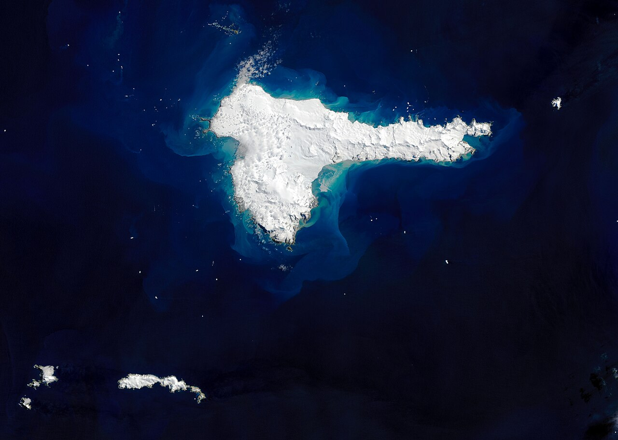

Imagem de satélite Landsat com diferentes tonalidades e coberturas

### Tonalidade

- Em imagens **pancromáticas** (P&B): escala de cinza (0 = preto, 255 = branco)
- Superfícies claras refletem mais → tons claros (solo exposto, areia, concreto)
- Superfícies escuras absorvem mais → tons escuros (água limpa, floresta densa, asfalto)

### Cor (composições coloridas)

- **Cor verdadeira** (RGB: 4-3-2) - aparência natural
- **Falsa cor** (RGB: 5-4-3 ou NIR-R-G) - vegetação em vermelho
- **Índices** (NDVI, NDWI) - destaca vegetação ou água

### Na análise de paisagem

A tonalidade/cor permite a **primeira separação** entre coberturas: vegetação, água, solo exposto, área urbana.

**Chave de tonalidade (exemplo para Sentinel-2, cor verdadeira)**

| Tonalidade/cor | Cobertura provável |
| --- | --- |
| Verde-escuro intenso | Floresta densa, vegetação arbórea |
| Verde-claro | Pastagem viçosa, capoeira, agricultura verde |
| Marrom/bege | Solo exposto, pastagem seca, preparo |
| Cinza/branco | Área urbana, rocha exposta, nuvem |
| Azul-escuro | Água profunda ou límpida |
| Azul-esverdeado | Água rasa ou turva / sedimento |
| Verde-amarelado | Vegetação estressada ou senescente |

> A tonalidade depende da **época** da imagem (seca vs. chuva), da **iluminação** e do **sensor**. Sempre considere a data!

## Textura, forma e padrão

[figure not shown]

### Textura

- **Lisa/fina** - superfícies uniformes (água calma, pastagem, solo preparado)
- **Rugosa/grosseira** - superfícies irregulares (copa de árvores, relevo acidentado)
- A textura depende da **resolução** do sensor - pixel de 10 m mostra textura diferente de pixel de 30 m

### Forma

- **Regular/geométrica** - ação humana (talhões, pivôs, lotes urbanos)
- **Irregular/orgânica** - processos naturais (fragmentos florestais, leitos fluviais)
- **Linear** - estradas, rios, corredores, linhas de transmissão
- **Circular** - pivôs centrais, crateras, represas circulares

**Padrão**

- **Repetição** de elementos → indica processo organizado
- Padrão **reticular** → malha urbana, irrigação
- Padrão **dendrítico** → drenagem natural
- Padrão **de faixas** → campos agrícolas, terraços
- Padrão **disperso** → ocupação rural difusa

### Na análise de paisagem

Textura, forma e padrão ajudam a distinguir:

- **Cobertura natural** (textura rugosa, forma irregular, padrão orgânico)
- **Uso antrópico** (textura lisa, forma geométrica, padrão repetitivo)
- **Degradação** (textura mista, forma irregular, padrão desorganizado)

> *“A paisagem antrópica impõe geometria; a paisagem natural responde com organicidade.”*

# 3 - CHAVES DE INTERPRETAÇÃO

## Chave de interpretação para a paisagem

| Feição | Tonalidade | Textura | Forma | Associação |
| --- | --- | --- | --- | --- |
| **Floresta densa** | Verde-escuro | Rugosa | Irregular | Encostas, APPs, topos |
| **Caatinga arbórea** | Verde-acinzentado | Média | Irregular | Áreas planas a suave-onduladas |
| **Caatinga degradada** | Marrom-esverdeado | Mista | Irregular | Solo exposto adjacente |
| **Pastagem** | Verde-claro a amarelado | Lisa | Irregular a poligonal | Cercas, estradas |
| **Agricultura** | Verde-claro homogêneo | Muito lisa | Geométrica (talhões) | Pivôs, estradas de terra |
| **Solo exposto** | Branco a marrom-claro | Lisa | Variável | Encostas degradadas, preparo |
| **Área urbana** | Cinza/branco misto | Fina, regular | Reticular | Estradas, aglomeração |
| **Corpo d’água** | Azul-escuro a preto | Muito lisa | Irregular (natural) ou regular (represa) | Rede de drenagem |
| **Voçoroca/erosão** | Branco/marrom-claro | Rugosa | Linear a irregular | Encostas, ausência de vegetação |

Esta chave é uma **referência inicial** para a região de Feira de Santana. Deve ser adaptada conforme o contexto local e a data da imagem.

# 4 - ROTEIRO DE INTERPRETAÇÃO

## Roteiro sistemático

### 6 passos para interpretar uma paisagem em imagem

1. **Visão geral** (zoom out)
   - Qual a extensão? Quantas “unidades” visuais distintas?
   - Qual é a matriz? Qual o grau de heterogeneidade?
2. **Identificação de classes**
   - Usando a chave de interpretação, classifique as principais coberturas
3. **Delimitação de manchas e corredores**
   - Onde estão os fragmentos? São grandes ou pequenos?
   - Existem conexões lineares (matas ciliares, cercas vivas)?
4. **Análise de relações**
   - Que relação existe entre relevo e uso? Entre drenagem e cobertura?

**Roteiro (continuação)**

5. **Identificação de processos e pressões**
   - Há evidências de desmatamento recente? Solo exposto? Erosão?
   - Há expansão urbana? Novas estradas?
6. **Síntese descritiva**
   - Texto que articula o que foi observado: componentes, padrões, relações, processos, pressões
   - Deve ser **descritivo-interpretativo** - não apenas lista de elementos, mas explicação das relações

### Produto

- **Texto** (1-2 parágrafos de síntese por unidade)
- **Anotações na imagem** (polígonos, setas, rótulos)
- **Perguntas** que demandam verificação em campo ou dados complementares

# 5 - EXERCÍCIO PRÁTICO

## Atividade: interpretação visual da área de estudo

### Proposta (individual ou em dupla, 35 min)

Usando a imagem de satélite da **área de estudo** definida na Aula 08:

1. **Aplique o roteiro de interpretação** (6 passos)
2. **Identifique e rotule** na imagem:
   - Matriz dominante
   - Pelo menos 5 manchas (com tipo: remanescente, introduzida, etc.)
   - Corredores visíveis (ou ausência deles)
   - Pelo menos 2 evidências de pressão antrópica
   - Pelo menos 1 evidência de processo natural
3. **Escreva** um parágrafo de síntese descritivo-interpretativo (7-10 frases)
4. **Formule** 3 perguntas que demandam mais investigação

### Socialização (15 min)

Duas duplas apresentam imagem anotada + síntese (5 min cada).

**Critérios**

| Critério | Peso |
| --- | --- |
| Aplicação correta dos elementos de interpretação | 25% |
| Identificação e classificação de feições | 25% |
| Qualidade da síntese descritiva | 30% |
| Perguntas analíticas formuladas | 20% |

> Este exercício compõe a **avaliação contínua** e será parte do dossiê.

## Síntese da Aula 09

**O que vimos hoje**

1. **Interpretação visual** - extração analítica de informações da imagem por olho treinado
2. **Oito elementos** - tonalidade, textura, forma, tamanho, sombra, padrão, associação, contexto
3. **Tonalidade e cor** - primeira triagem de coberturas; depende do sensor e da data
4. **Textura, forma e padrão** - distinguem natural de antrópico; indicam processos
5. **Chave de interpretação** - referência para feições típicas da paisagem regional
6. **Roteiro de 6 passos** - visão geral → classes → manchas/corredores → relações → pressões → síntese
7. **Síntese descritivo-interpretativa** - articulação textual de padrões, processos e relações

Obrigado!

Luiz Diego Vidal Santos

Universidade Estadual de Feira de Santana (UEFS)

Análise da Paisagem - Aula 09